# week_02_09_09_2021

## CMPINF 2100 Fall 2021 - Week 02

### Example builds on Week 02 readings

Let's first check the environment.

```python
%whos
```

```
Interactive namespace is empty.
```

## Random numbers

We will create random numbers using the `random` module.

```python
import random
```

```python
%whos
```

```
Variable   Type      Data/Info
------------------------------
random     module    <module 'random' from 'C:<...>inf2100\\lib\\random.py'>
```

We need to use the "DOT NOTATION" to call a function from the module.

```python
dir(random)
```

```
['BPF',
 'LOG4',
 'NV_MAGICCONST',
 'RECIP_BPF',
 'Random',
 'SG_MAGICCONST',
 'SystemRandom',
 'TWOPI',
 '_Sequence',
 '_Set',
 '__all__',
 '__builtins__',
 '__cached__',
 '__doc__',
 '__file__',
 '__loader__',
 '__name__',
 '__package__',
 '__spec__',
 '_accumulate',
 '_acos',
 '_bisect',
 '_ceil',
 '_cos',
 '_e',
 '_exp',
 '_inst',
 '_log',
 '_os',
 '_pi',
 '_random',
 '_repeat',
 '_sha512',
 '_sin',
 '_sqrt',
 '_test',
 '_test_generator',
 '_urandom',
 '_warn',
 'betavariate',
 'choice',
 'choices',
 'expovariate',
 'gammavariate',
 'gauss',
 'getrandbits',
 'getstate',
 'lognormvariate',
 'normalvariate',
 'paretovariate',
 'randint',
 'random',
 'randrange',
 'sample',
 'seed',
 'setstate',
 'shuffle',
 'triangular',
 'uniform',
 'vonmisesvariate',
 'weibullvariate']
```

Setting the random seed.

```python
random.seed(2100)
```

Let's generate a random number. This random number will be between 0 and 1.

```python
random.random()
```

```
0.764021138054951
```

```python
random.random()
```

```
0.4692037101382426
```

Let's reset the seed back to the original number that we used.

```python
random.seed(2100)

print( random.random() )

print( random.random() )
```

```
0.764021138054951
0.4692037101382426
```

Let's store random numbers in a list.

```python
random.seed(20)

x_a = [ random.random(), random.random() ]

random.seed(20)

x_b = [ random.random(), random.random() ]
```

```python
%whos
```

```
Variable   Type      Data/Info
------------------------------
random     module    <module 'random' from 'C:<...>inf2100\\lib\\random.py'>
x_a        list      n=2
x_b        list      n=2
```

```python
print( x_a )

print( x_b )
```

```
[0.9056396761745207, 0.6862541570267026]
[0.9056396761745207, 0.6862541570267026]
```

```python
x_a == x_b
```

```
True
```

```python
x_a is x_b
```

```
False
```

## Multiple random numbers

If we're using `random.random()` we need to **iterate** to create a sequence of multiple random numbers.

First review basic structure of the for-loop:

```python
for n in range(7):
    print(n)
```

```
0
1
2
3
4
5
6
```

```python
%whos
```

```
Variable   Type      Data/Info
------------------------------
n          int       6
random     module    <module 'random' from 'C:<...>inf2100\\lib\\random.py'>
x_a        list      n=2
x_b        list      n=2
```

```python
for nn in range(7):
    print( n + nn )
```

```
6
7
8
9
10
11
12
```

```python
for mm in range(7):
    print( "%d + %d = %d" % (nn, mm, nn+mm))
```

```
6 + 0 = 6
6 + 1 = 7
6 + 2 = 8
6 + 3 = 9
6 + 4 = 10
6 + 5 = 11
6 + 6 = 12
```

Now use a for-loop for our random number generator.

```python
random.seed(11)

for n in range(7):
    print( random.random() )
```

```
0.4523795535098186
0.559772386080496
0.9242105840237294
0.4656500700997733
0.5078412730622711
0.587384828849897
0.18466034385487662
```

To store the random numbers in a list we must **initialize** the list.

Then each iteration we can add to the list.

```python
xu = []

print( len(xu) )
```

```
0
```

Check the methods for the list object data type.

```python
%whos
```

```
Variable   Type      Data/Info
------------------------------
mm         int       6
n          int       6
nn         int       6
random     module    <module 'random' from 'C:<...>inf2100\\lib\\random.py'>
x_a        list      n=2
x_b        list      n=2
xu         list      n=0
```

```python
dir(xu)
```

```
['__add__',
 '__class__',
 '__contains__',
 '__delattr__',
 '__delitem__',
 '__dir__',
 '__doc__',
 '__eq__',
 '__format__',
 '__ge__',
 '__getattribute__',
 '__getitem__',
 '__gt__',
 '__hash__',
 '__iadd__',
 '__imul__',
 '__init__',
 '__init_subclass__',
 '__iter__',
 '__le__',
 '__len__',
 '__lt__',
 '__mul__',
 '__ne__',
 '__new__',
 '__reduce__',
 '__reduce_ex__',
 '__repr__',
 '__reversed__',
 '__rmul__',
 '__setattr__',
 '__setitem__',
 '__sizeof__',
 '__str__',
 '__subclasshook__',
 'append',
 'clear',
 'copy',
 'count',
 'extend',
 'index',
 'insert',
 'pop',
 'remove',
 'reverse',
 'sort']
```

```python
random.seed(11)

for ix in range(7):
    xu.append( random.random() )
    print( "the list has length: " + str(len(xu)) )
```

```
the list has length: 1
the list has length: 2
the list has length: 3
the list has length: 4
the list has length: 5
the list has length: 6
the list has length: 7
```

```python
"the list has length: " + len(xu)
```

```
---------------------------------------------------------------------------
TypeError                                 Traceback (most recent call last)
~\AppData\Local\Temp/ipykernel_23224/3998419058.py in <module>
----> 1 "the list has length: " + len(xu)

TypeError: can only concatenate str (not "int") to str
```

```python
"the list has length: " + str( len(xu) )
```

```
'the list has length: 7'
```

```python
print( xu )
```

```
[0.4523795535098186, 0.559772386080496, 0.9242105840237294, 0.4656500700997733, 0.5078412730622711, 0.587384828849897, 0.18466034385487662]
```

What happens if we forget to initialize the list?

```python
random.seed(11)

for ix in range(7):
    xu_b.append( random.random() )
```

```
---------------------------------------------------------------------------
NameError                                 Traceback (most recent call last)
~\AppData\Local\Temp/ipykernel_23224/1127568094.py in <module>
      2
      3 for ix in range(7):
----> 4     xu_b.append( random.random() )

NameError: name 'xu_b' is not defined
```

## List comprehension

The basic steps in the iteration are:

- The action
- The iterating variable
- the sequence to iterate over

The structure of a list comprehensions:

`<output list> = [ <action per value of iterating variable> for <variable> in <sequence to iterate over> ]`

Let's now use the list comprehension to generate 7 random numbers and store them in a list.

```python
random.seed(11)

xu_c = [random.random() for iterating_variable in range(7)]
```

```python
%whos
```

```
Variable   Type      Data/Info
------------------------------
ix         int       0
mm         int       6
n          int       6
nn         int       6
random     module    <module 'random' from 'C:<...>inf2100\\lib\\random.py'>
x_a        list      n=2
x_b        list      n=2
xu         list      n=7
xu_c       list      n=7
```

```python
print( xu )

print( xu_c )
```

```
[0.4523795535098186, 0.559772386080496, 0.9242105840237294, 0.4656500700997733, 0.5078412730622711, 0.587384828849897, 0.18466034385487662]
[0.4523795535098186, 0.559772386080496, 0.9242105840237294, 0.4656500700997733, 0.5078412730622711, 0.587384828849897, 0.18466034385487662]
```

```python
print( xu == xu_c )
```

```
True
```

Convention in list comprehensions is to set the iterating variable to an underscore when we don't need it.

```python
random.seed(11)

xu_d = [random.random() for _ in range(7)]
```

```python
%whos
```

```
Variable   Type      Data/Info
------------------------------
ix         int       0
mm         int       6
n          int       6
nn         int       6
random     module    <module 'random' from 'C:<...>inf2100\\lib\\random.py'>
x_a        list      n=2
x_b        list      n=2
xu         list      n=7
xu_c       list      n=7
xu_d       list      n=7
```

```python
print(xu == xu_d)
```

```
True
```

## Calculating the average

How do we calculate the average of $N$ numbers? Specifically, how do we calculate the average of $N$ numbers, $x_n$ where $n=1,...,N$?

$$\bar{x} = \frac{1}{N} \sum_{n=1}^{N} \left( x_n \right)$$

Let's try this out manually first.

```python
1 + 2 + 3
```

```
6
```

```python
print( sum([1, 2, 3]) )
```

```
6
```

```python
len([1, 2, 3])
```

```
3
```

```python
(1 + 2 + 3) / 3
```

```
2.0
```

```python
print( sum([1, 2, 3]) / len([1, 2, 3]) )
```

```
2.0
```

Let's create our own function to calculate the average for us.

```python
def my_avg(x):
    """
    calculate the average of a list of integers or floats
    """
    return sum(x) / len(x)
```

```python
%whos
```

```
Variable   Type        Data/Info
--------------------------------
ix         int         0
mm         int         6
my_avg     function    <function my_avg at 0x00000125FE27EA60>
n          int         6
nn         int         6
random     module      <module 'random' from 'C:<...>inf2100\\lib\\random.py'>
x_a        list        n=2
x_b        list        n=2
xu         list        n=7
xu_c       list        n=7
xu_d       list        n=7
```

```python
my_avg
```

```
<function __main__.my_avg(x)>
```

```python
my_avg()
```

```
---------------------------------------------------------------------------
TypeError                                 Traceback (most recent call last)
~\AppData\Local\Temp/ipykernel_23224/3633098130.py in <module>
----> 1 my_avg()

TypeError: my_avg() missing 1 required positional argument: 'x'
```

```python
my_avg([1, 2, 3])
```

```
2.0
```

```python
my_avg([1.0, 2.0, 3.0])
```

```
2.0
```

```python
my_avg([1, 2.0, 3])
```

```
2.0
```

```python
my_avg(['frodo', 'merry', 'sam'])
```

```
---------------------------------------------------------------------------
TypeError                                 Traceback (most recent call last)
~\AppData\Local\Temp/ipykernel_23224/3560329141.py in <module>
----> 1 my_avg(['frodo', 'merry', 'sam'])

~\AppData\Local\Temp/ipykernel_23224/2895675914.py in my_avg(x)
      3     calculate the average of a list of integers or floats
      4     """
----> 5     return sum(x) / len(x)

TypeError: unsupported operand type(s) for +: 'int' and 'str'
```

## Apply our average function

Create 2 lists of 7 random numbers generated uniformly between 0 and 1.

```python
random.seed(21)

yu = [ random.random() for _ in range(7) ]

zu = [ random.random() for _ in range(7) ]
```

```python
print( yu )

print( zu )
```

```
[0.16494947983319797, 0.6897669242175674, 0.6349999404047206, 0.4791004720574512, 0.21601434789390284, 0.7926333582002464, 0.8078543019534277]
[0.5124562396375931, 0.5050841534700117, 0.2360563634962105, 0.0031806306102971638, 0.3710466916321078, 0.5853624971821242, 0.06926476318331132]
```

```python
print(yu == zu)
```

```
False
```

Just what the seed does.

```python
random.seed(21)

yu_b = [ random.random() for _ in range(7) ]

zu_b = [ random.random() for _ in range(7) ]
```

```python
print( yu == yu_b )

print( zu == zu_b )
```

```
True
True
```

What is the average of our 7 random numbers?

```python
print( my_avg(yu) )

print( my_avg(zu) )
```

```
0.5407598320800735
0.3260644770302365
```

Which is the correct average?

## Plotting with matplotlib

```python
import matplotlib.pyplot as plt
```

```python
%whos
```

```
Variable   Type        Data/Info
--------------------------------
ix         int         0
mm         int         6
my_avg     function    <function my_avg at 0x00000125FE27EA60>
n          int         6
nn         int         6
plt        module      <module 'matplotlib.pyplo<...>\\matplotlib\\pyplot.py'>
random     module      <module 'random' from 'C:<...>inf2100\\lib\\random.py'>
x_a        list        n=2
x_b        list        n=2
xu         list        n=7
xu_c       list        n=7
xu_d       list        n=7
yu         list        n=7
yu_b       list        n=7
zu         list        n=7
zu_b       list        n=7
```

To give some context to the random numbers generated, let's generate 1000 random numbers from `random.random()`.

```python
random.seed(24)

xu_1000 = [ random.random() for _ in range(1000) ]
```

```python
print( len(xu_1000) )
```

```
1000
```

```python
xu_1000[:5]
```

```
[0.7123429878269185,
 0.8397997363118733,
 0.18259188695451745,
 0.9982826275179507,
 0.19409547872374744]
```

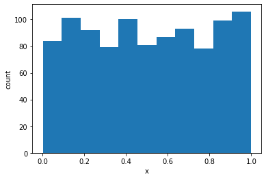

```python
plt.hist(xu_1000, bins=11)
plt.xlabel('x')
plt.ylabel('count')
plt.show()
```

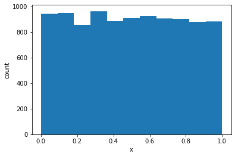

```python
plt.hist([random.random() for _ in range(10000)], bins=11)
plt.xlabel('x')
plt.ylabel('count')
plt.show()
```

Calculate the average based on the 1000 random samples.

```python
print( my_avg(xu_1000) )
```

```
0.5077442149000129
```

```python
print( my_avg([random.random() for _ in range(int(1e6))]) )
```

```
0.5003029679189047
```

```python
1e6
```

```
1000000.0
```

```python
int(1e6)
```

```
1000000
```

Let's go back to our 7 samples.

```python
print( my_avg(yu) )

print( my_avg(zu) )
```

```
0.5407598320800735
0.3260644770302365
```

**How confident are we in our estimate of the average?**

## Simulation

Study the variability of the average.

The major steps in our simulation:

- Generate a sequence of random numbers from an assumed distribution
- Calculate the sample average given that sequence

```python
def gen_samples_calc_avg(N):
    """ assume we are working with a uniform distribution between 0 and 1 """
    return my_avg( [random.random() for _ in range(N)] )
```

```python
%whos
```

```
Variable               Type        Data/Info
--------------------------------------------
gen_samples_calc_avg   function    <function gen_samples_cal<...>vg at 0x000001258057E670>
ix                     int         0
mm                     int         6
my_avg                 function    <function my_avg at 0x00000125FE27EA60>
n                      int         6
nn                     int         6
plt                    module      <module 'matplotlib.pyplo<...>\\matplotlib\\pyplot.py'>
random                 module      <module 'random' from 'C:<...>inf2100\\lib\\random.py'>
x_a                    list        n=2
x_b                    list        n=2
xu                     list        n=7
xu_1000                list        n=1000
xu_c                   list        n=7
xu_d                   list        n=7
yu                     list        n=7
yu_b                   list        n=7
zu                     list        n=7
zu_b                   list        n=7
```

```python
print( my_avg(yu) )
```

```
0.5407598320800735
```

Confirm we can get the same result.

```python
random.seed(21)

check_yu_avg = gen_samples_calc_avg(7)
```

```python
print( check_yu_avg )
```

```
0.5407598320800735
```

```python
print( check_yu_avg == my_avg(yu) )
```

```
True
```

Run a simulation of calculating the average of 7 randomly generated numbers.

```python
random.seed(51)

print( gen_samples_calc_avg(7) )

print( gen_samples_calc_avg(7) )

print( gen_samples_calc_avg(7) )

print( gen_samples_calc_avg(7) )

print( gen_samples_calc_avg(7) )

print( gen_samples_calc_avg(7) )

print( gen_samples_calc_avg(7) )

print( gen_samples_calc_avg(7) )

print( gen_samples_calc_avg(7) )
```

```
0.49128172289705047
0.6028632187643036
0.571620183697683
0.6356428162727541
0.6559850095614302
0.6695290749120935
0.4347190094100539
0.43845567833254806
0.8157455952566638
```

Let's **replicate** or **repeat** the calculating the average 1000 times.

```python
random.seed(51)

xbar_sim_N07_R1000 = [ gen_samples_calc_avg(7) for _ in range(1000) ]
```

```python
print( len(xbar_sim_N07_R1000) )
```

```
1000
```

```python
print( type(xbar_sim_N07_R1000) )
```

```
<class 'list'>
```

```python
print( xbar_sim_N07_R1000[:6])
```

```
[0.49128172289705047, 0.6028632187643036, 0.571620183697683, 0.6356428162727541, 0.6559850095614302, 0.6695290749120935]
```

We can calculate the **average of the averages**.

```python
print( my_avg( xbar_sim_N07_R1000 ) )
```

```
0.5044399287376922
```

```python
print( round( my_avg(xbar_sim_N07_R1000), 4) )
```

```
0.5044
```

We did the simulation to study the **variability** or the **distribution** of the average.

Let's use a histogram to visualize the distribution of the averages.

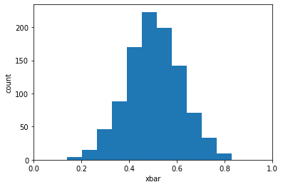

```python
plt.hist(xbar_sim_N07_R1000, bins=11)
plt.xlabel('xbar')
plt.ylabel('count')
plt.xlim(0, 1)
plt.show()
```

Let's try again but with 10000 replications.

```python
random.seed(51)

xbar_sim_N07_R1e4 = [ gen_samples_calc_avg(7) for _ in range(int(1e4)) ]
```

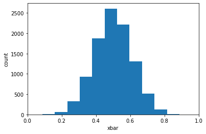

```python
plt.hist(xbar_sim_N07_R1e4, bins=11)
plt.xlabel('xbar')
plt.ylabel('count')
plt.xlim(0, 1)
plt.show()
```

What if we had a few replications? For example what if we had 11?

```python
random.seed(51)

xbar_sim_N07_R0011 = [ gen_samples_calc_avg(7) for _ in range(11) ]
```

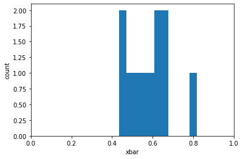

```python
plt.hist(xbar_sim_N07_R0011, bins=11)
plt.xlabel('xbar')
plt.ylabel('count')
plt.xlim(0, 1)
plt.show()
```

Let's try many different replication sizes.

```python
num_replications = [ 5 * (2 ** ix) for ix in range(12) ]

print(num_replications)
```

```
[5, 10, 20, 40, 80, 160, 320, 640, 1280, 2560, 5120, 10240]
```

```python
# how enumerate works

for i, nr in enumerate(num_replications):
    print( i, nr )
```

```
0 5
1 10
2 20
3 40
4 80
5 160
6 320
7 640
8 1280
9 2560
10 5120
11 10240
```

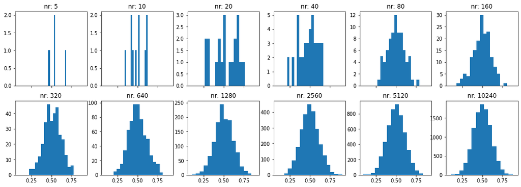

```python
fig, axs = plt.subplots(2, 6, figsize=(18,6), sharex=True, sharey=False)

axs = axs.ravel()

random.seed(801)
for i, nr in enumerate(num_replications):
    axs[i].hist( [gen_samples_calc_avg(7) for _ in range(nr)], density=False, bins=15)
    axs[i].set_title("nr: " + str(nr))
```

What is the above process called?

This is the CENTRAL LIMIT THM!!!!!!

## Sample variance

The formula for the sample variance is:

$$s^2 = \frac{1}{N-1} \sum_{n=1}^{N} \left( \left(x_n - \bar{x} \right)^2 \right) $$

Let's define a function to calculate the sample variance from a list of numbers.

```python
def my_variance(x):
    xbar = my_avg(x)
    squared_deviation = [ (xn - xbar) ** 2 for xn in x ]
    return sum(squared_deviation) / (len(x) - 1)
```

Check to make sure the function works.

```python
print( my_variance([1, 2, 3]) )
```

```
1.0
```

```python
print( my_variance([5, 10, 15]) )
```

```
25.0
```

Re execute the simulation where we calculate the variance of the average, but for a different set of replications.

```python
num_replications_study = [5 * (2 ** ix) for ix in range(16)]

print( num_replications_study)
```

```
[5, 10, 20, 40, 80, 160, 320, 640, 1280, 2560, 5120, 10240, 20480, 40960, 81920, 163840]
```

Let's manage the two levels of iterations completely with list comprehensions.

We have nested list comprehensions. Start with the outer most result.

`<list of variances of the avg> = [<variance of the avg given reps> for <num reps> in <sequence of number of replications>]`

How do we calculate the variance?

`my_variance(<list of randomly generated average>)`

The inner most iteration must generate the list of averages for a given number of replications.

```python
random.seed(9213)

study_variance_N07 = [my_variance([gen_samples_calc_avg(7) for _ in range(nrr)]) for nrr in num_replications_study]
```

Let's visualize the sample variance with respect to the number of replications.

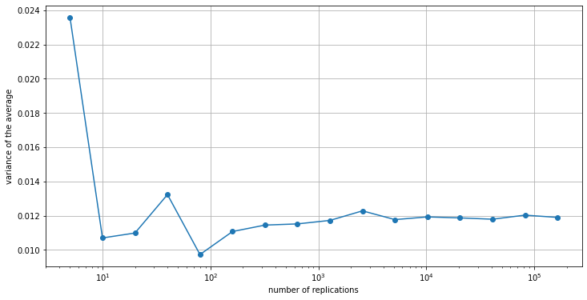

```python
fig, ax = plt.subplots(figsize=(12,6))

ax.plot(num_replications_study, study_variance_N07, '-o')
ax.set_xscale('log')
ax.set_xlabel('number of replications')
ax.set_ylabel('variance of the average')
ax.grid(True)
plt.show()
```

When we describe the uncertainty on the average we typically talk in terms of the **standard deviation**.

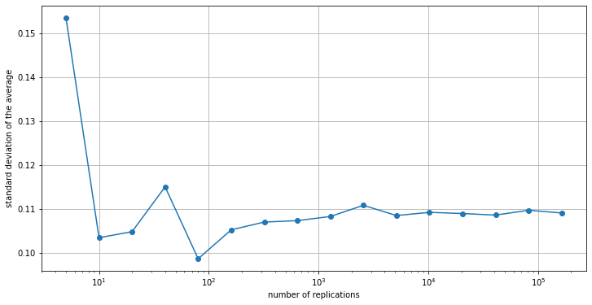

```python
fig, ax = plt.subplots(figsize=(12,6))

ax.plot(num_replications_study, [xv ** 0.5 for xv in study_variance_N07], '-o')
ax.set_xscale('log')
ax.set_xlabel('number of replications')
ax.set_ylabel('standard deviation of the average')
ax.grid(True)
plt.show()
```

## Effect of sample size

Fix the replication size (so we have a stable estimate) but study the impact of the **sample size** on the variability of the average.

Define a set of sample sizes to examine.

```python
sample_size_study = [ 3 * (2 ** ix) for ix in range(15) ]
```

```python
print( sample_size_study )
```

```
[3, 6, 12, 24, 48, 96, 192, 384, 768, 1536, 3072, 6144, 12288, 24576, 49152]
```

First, let's visualize the distribution of the average as we change the sample size.

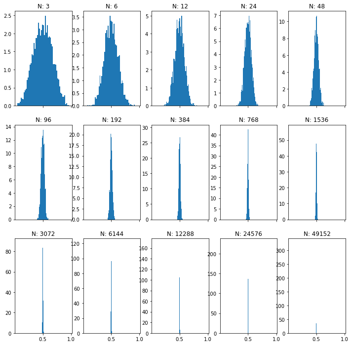

```python
fig, axs = plt.subplots(3, 5, figsize=(12, 12), sharex=True, sharey=False)

axs = axs.ravel()

random.seed(801)

for i, n in enumerate(sample_size_study):
    axs[i].hist( [gen_samples_calc_avg(n) for _ in range(2500)], density=True, bins=51)
    axs[i].set_title("N: " + str(n))
```

We can see this again by focusing on the variance of the averages.

```python
random.seed(9213)

study_variance_vs_samplesize = [my_variance([gen_samples_calc_avg(n) for _ in range(2500)]) for n in sample_size_study]
```

Visualize the standard deviation of the average with respect to sample size.

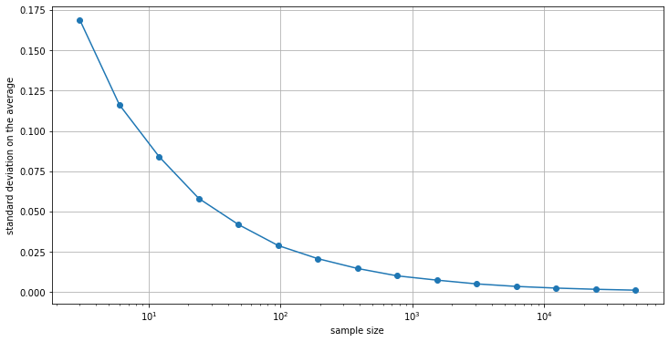

```python
fig, ax = plt.subplots(figsize=(12,6))

ax.plot(sample_size_study, [xv**0.5 for xv in study_variance_vs_samplesize], '-o')
ax.set_xscale('log')
ax.set_xlabel('sample size')
ax.set_ylabel('standard deviation on the average')
ax.grid(True)
plt.show()
```

The standard deviation of the average is known as the **standard error of the mean**

### Theoretical result

The standard error on the average is:

$$ se = \frac{\sigma}{\sqrt{N}} $$

Where $\sigma$ is the sampling distribution standard deviation.

The variance of a uniform distribution between $a$ and $b$ is:

$$ Var = \frac{1}{12} \left(b - a\right)^2 $$

Our specific uniform distribution is between zero and one, so the variance is:

$$ Var = \frac{1}{12} $$

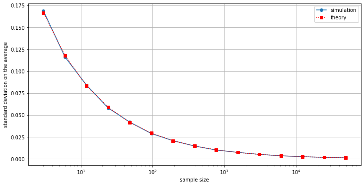

```python
fig, ax = plt.subplots(figsize=(12,6))

ax.plot(sample_size_study, [xv**0.5 for xv in study_variance_vs_samplesize], '-o', label='simulation')
ax.plot(sample_size_study, [((1/12)/n)**0.5 for n in sample_size_study], ':sr', label='theory')
ax.set_xscale('log')
ax.set_xlabel('sample size')
ax.set_ylabel('standard deviation on the average')
ax.grid(True)
ax.legend()
plt.show()
```

To generate random numbers from other distributions:

https://docs.python.org/3/library/random.html#real-valued-distributions

```python
random.gauss(mu=1001, sigma=890)
```

```
-244.7213430711413
```

## How can we use this?

We have finite samples of usually small sizes of things.

How confident are we on the average estimate?

```python
print( yu )
```

```
[0.16494947983319797, 0.6897669242175674, 0.6349999404047206, 0.4791004720574512, 0.21601434789390284, 0.7926333582002464, 0.8078543019534277]
```

```python
print( round(my_avg(yu), 4) )
```

```
0.5408
```

The **95% confidence interval** is the sample average $\pm$ 2 times the standard error.

```python
conf_int = (my_avg(yu) - 2*(my_variance(yu) / len(yu))**0.5, my_avg(yu) + 2*(my_variance(yu) / len(yu))**0.5)
```

```python
conf_int
```

```
(0.34162863159846696, 0.7398910325616801)
```

```python
(my_avg(zu) - 2*(my_variance(zu) / len(zu))**0.5, my_avg(zu) + 2*(my_variance(zu) / len(zu))**0.5)
```

```
(0.15303810182680433, 0.49909085223366867)
```